# Cytokine Profiles for Brescia Deceased vs. Recovered

Compare cytokine profiles between deceased patients and those with good outcome. Specific focus on 17-23 days since symptom onset.

### Create sub-cohort

Identify all deceased patients and match them with critical but recovered patients by age and gender (excluding those staying hospitalized for more than 50 days). Patients in the citiseq cohort can optionally be excluded.

```r
load(file.path(data.folder,"covid19.metadata.paper1.RData"),verbose=F)
covid19.lab.results$severity.outcome <- paste0(covid19.lab.results$severity,"-",covid19.lab.results$outcome)

severity.color <- c("Critical-Alive"="#374E55FF","Critical-Deceased"="#DF8F44FF","Moderate-Alive"="#00A1D5FF" ,"Severe-Alive"="#B24745FF","HC" = "#79AF97FF")

deceased.patients.cytokines <- subset(covid19.lab.results,outcome == "Deceased" & test_type == "ELISA" & !is.na(days_from_symptom_onset_to_test))
deceased.patients <- unique(deceased.patients.cytokines$subject_id)

cat("Map of sampling TSO time points for deceased patients:\n")
```

```
## Map of sampling TSO time points for deceased patients:
```

```r
deceased.time.points <- as.data.frame.matrix(table(deceased.patients.cytokines[,c("subject_id","days_from_symptom_onset_to_test")]))
colSums(deceased.time.points > 0)
```

```
##  3  8 10 11 12 13 14 16 17 18 19 20 21 22 23 24 25 26 28 29 30 32 35 36 39 42
##  1  1  1  3  1  2  1  2  1  1  2  3  1  4  1  3  3  2  1  2  1  1  2  2  2  1
## 45 47 53
##  1  2  1
```

```r
cat("Age and sex distribution:\n")
```

```
## Age and sex distribution:
```

```r
table(subset(covid19.patient.demo,subject_id %in% deceased.patients)$sex)
```

```
##
##  F  M
##  2 15
```

```r
summary(subset(covid19.patient.demo,subject_id %in% deceased.patients)$age)
```

```
##    Min. 1st Qu.  Median    Mean 3rd Qu.    Max.
##   46.00   61.00   66.00   66.24   73.00   78.00
```

```r
# recovered patients with similar age and sex
age.tol <- 3
recovered.patients <- c()
for (i in deceased.patients) {
  target.age <- covid19.patient.demo[i,"age"]
  target.sex <- covid19.patient.demo[i,"sex"]
  cat("Target age:",target.age,"sex:",target.sex,"\n")
  tmp <- subset(covid19.lab.results,outcome != "Deceased" & test_type == "ELISA" & !is.na(days_from_symptom_onset_to_test) &
           age >= target.age - age.tol & age <= target.age + age.tol & severity == "Critical" & sex == target.sex &
             days_from_symptom_onset_to_test > 15 & days_from_symptom_onset_to_test <= 25 &
           number_of_days_hospitalized < 50)

  matched.subject <- unique(tmp$subject_id)
  cat("Matched subject:",matched.subject,"\n")
  recovered.patients <- c(recovered.patients,matched.subject)
}
```

```
## Target age: 73 sex: M
## Matched subject: HGR0000015 HGR0000088 HGR0000093 HGR0000101
## Target age: 65 sex: M
## Matched subject: HGR0000039 HGR0000077
## Target age: 66 sex: M
## Matched subject: HGR0000063 HGR0000085 HGR0000149
## Target age: 59 sex: M
## Matched subject: HGR0000039 HGR0000049 HGR0000077 HGR0000102 HGR0000108 HGR0000135
## Target age: 46 sex: M
## Matched subject: HGR0000032 HGR0000092 HGR0000142 HGR0000145
## Target age: 66 sex: M
## Matched subject: HGR0000063 HGR0000085 HGR0000149
## Target age: 78 sex: M
## Matched subject: HGR0000088 HGR0000089
## Target age: 61 sex: M
## Matched subject: HGR0000039 HGR0000077 HGR0000102 HGR0000135
## Target age: 68 sex: M
## Matched subject: HGR0000063 HGR0000085 HGR0000093 HGR0000149
## Target age: 71 sex: F
## Matched subject:
## Target age: 66 sex: M
## Matched subject: HGR0000063 HGR0000085 HGR0000149
## Target age: 49 sex: F
## Matched subject: HGR0000044 HGR0000075 HGR0000139
## Target age: 73 sex: M
## Matched subject: HGR0000015 HGR0000088 HGR0000093 HGR0000101
## Target age: 76 sex: M
## Matched subject: HGR0000015 HGR0000088 HGR0000089 HGR0000101
## Target age: 60 sex: M
## Matched subject: HGR0000039 HGR0000049 HGR0000077 HGR0000102 HGR0000135
## Target age: 72 sex: M
## Matched subject: HGR0000015 HGR0000063 HGR0000085 HGR0000093 HGR0000101 HGR0000149
## Target age: 77 sex: M
## Matched subject: HGR0000015 HGR0000088 HGR0000089
```

```r
recovered.patients <- unique(recovered.patients[!is.na(recovered.patients)])
recovered.patients.cytokines <- subset(covid19.lab.results,test_type == "ELISA" & subject_id %in% recovered.patients)
cat("Map of samping TSO time points for recovered patients:\n")
```

```
## Map of samping TSO time points for recovered patients:
```

```r
recovered.time.points <- as.data.frame.matrix(table(recovered.patients.cytokines[,c("subject_id","days_from_symptom_onset_to_test")]))
colSums(recovered.time.points > 0)
```

```
##  3  8  9 10 11 12 13 14 15 16 17 18 19 20 22 23 24 25 26 27 29 30 31 32 33 34
##  1  1  1  3  2  2  3  3  4  4  2  5  5  6  1  5  2  3  2  3  2  3  2  1  2  1
## 35 37 38 39 40 44 45 48 51 56
##  2  1  1  1  1  2  1  1  1  1
```

```r
cat("Age and sex distribution:\n")
```

```
## Age and sex distribution:
```

```r
table(subset(covid19.patient.demo,subject_id %in% recovered.patients)$sex)
```

```
##
##  F  M
##  3 18
```

```r
summary(subset(covid19.patient.demo,subject_id %in% recovered.patients)$age)
```

```
##    Min. 1st Qu.  Median    Mean 3rd Qu.    Max.
##   45.00   49.00   59.00   60.33   69.00   78.00
```

```r
selected.cytokine.profiles <- rbind(deceased.patients.cytokines,recovered.patients.cytokines)
# remove patients in citeseq
#citeseq.patients <- subset(covid19.samples,!is.na(batch))$subject_id
#intersect(citeseq.patients,c(recovered.patients,deceased.patients))
#selected.cytokine.profiles <- subset(selected.cytokine.profiles,!(subject_id %in% citeseq.patients))
parameter.labels <- unique(selected.cytokine.profiles[,c("test_id","test_name")])
rownames(parameter.labels) <- parameter.labels$test_id
parameter.labels$test_name <- gsub("/ ","/",parameter.labels$test_name,fixed = T)
```

### Grouping of samples

Separate samples into interval groups relative to juncture: early (7-16 days), mid (juncture/17-23 days), and late (24-30 days)

```r
selected.cytokine.profiles$unique.id <- make.unique(apply(selected.cytokine.profiles[,c("subject_id","days_from_admission_to_test","test_id")],1,
                                                          paste0,collapse="."),sep = "|")
selected.cytokine.profiles$unique.id <- sapply(selected.cytokine.profiles$unique.id,function(x){unlist(strsplit(x,"|",fixed=T))[2]})
selected.cytokine.profiles.matrix <- reshape2::dcast(selected.cytokine.profiles,
                                                     subject_id + age + sex + outcome + severity + days_from_symptom_onset_to_test + unique.id ~ test_id,
                                                     value.var = "test_value")
selected.cytokine.profiles.matrix[,colnames(selected.cytokine.profiles.matrix) %in% selected.cytokine.profiles$test_id] <-
  apply(selected.cytokine.profiles.matrix[,colnames(selected.cytokine.profiles.matrix) %in% selected.cytokine.profiles$test_id],2,function(x){scale(log10(x+1))})
selected.cytokine.profiles.matrix$stage <- NA
tmp <- which(selected.cytokine.profiles.matrix$days_from_symptom_onset_to_test >= 7 & selected.cytokine.profiles.matrix$days_from_symptom_onset_to_test <= 16)
selected.cytokine.profiles.matrix[tmp,"stage"] <- "early"
tmp <- which(selected.cytokine.profiles.matrix$days_from_symptom_onset_to_test >= 17 & selected.cytokine.profiles.matrix$days_from_symptom_onset_to_test <= 23)
selected.cytokine.profiles.matrix[tmp,"stage"] <- "mid"
tmp <- which(selected.cytokine.profiles.matrix$days_from_symptom_onset_to_test >= 24 & selected.cytokine.profiles.matrix$days_from_symptom_onset_to_test <= 30)
selected.cytokine.profiles.matrix[tmp,"stage"] <- "late"

cat("Sample distribution:\n")
```

```
## Sample distribution:
```

```r
table(selected.cytokine.profiles.matrix[,c("outcome","stage")])
```

```
##           stage
## outcome    early late mid
##   Alive       24   16  25
##   Deceased    11   12  13
```

#### Protein Search

Search for divergent proteins around juncture using these two models:

Differential expression: test_value ~ outcome + age.numeric + sex + DFSO + (1|subject_id), for samples within each stage to identify cytokines with sig. differences between the two outcome groups

Change between intervals: test_value ~ outcome*stage + age.numeric + sex + DFSO + (1|subject_id), the outcome:stage term captures difference in differences between the two groups entering the juncture and post-juncture

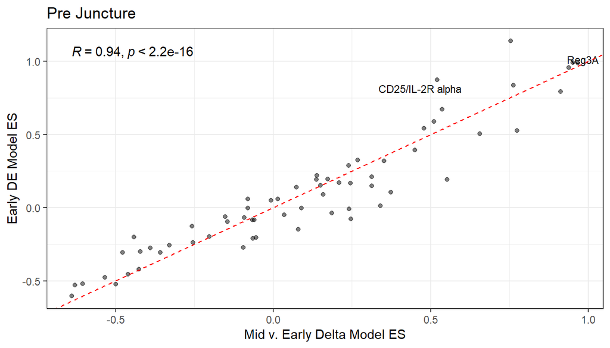

```r
search.results <- juncture.divergent.proteins(selected.cytokine.profiles.matrix,pval.cutoff = 1)
parameter.labels <- unique(selected.cytokine.profiles[,c("test_id","test_name")])
rownames(parameter.labels) <- parameter.labels$test_id
parameter.labels$test_name <- gsub("/ ","/",parameter.labels$test_name,fixed = T)
search.results$type1$cytokine.label <- parameter.labels[search.results$type1$cytokine,"test_name"]
search.results$type1$de.coef.outcomeDeceased.diff.from.early <- search.results$type1$de.coef.outcomeDeceased -
                                                                      search.results$type1$de.coef.outcomeDeceased.early
search.results$type1$de.coef.outcomeDeceased.inferred <- search.results$type1$did.coef.outcomeDeceased +
  search.results$type1$did.coef.test.intervalTRUE.outcomeDeceased


# bubble plots of DE and change effects
#pdf(file.path(output.folder,"critical.juncture","deceased.v.recovered.sig.de.and.change.cytokines.pdf"),width=3,height = 3)

# correlation between different models
mid.did.de.df <- subset(search.results$type1,stage == "mid")
ggplot(mid.did.de.df,aes(did.coef.outcomeDeceased,de.coef.outcomeDeceased.early,label=cytokine.label)) +
  geom_point(alpha=0.5) + ggrepel::geom_text_repel(data=subset(mid.did.de.df,cytokine.label %in% c("Reg3A","CD25/IL-2R alpha")),size=3) +
  stat_cor() + geom_abline(intercept = 0,slope = 1, color="red", linetype = "dashed") +
  theme_bw()  + labs(title="Pre Juncture",x="Mid v. Early Delta Model ES",y="Early DE Model ES")
```

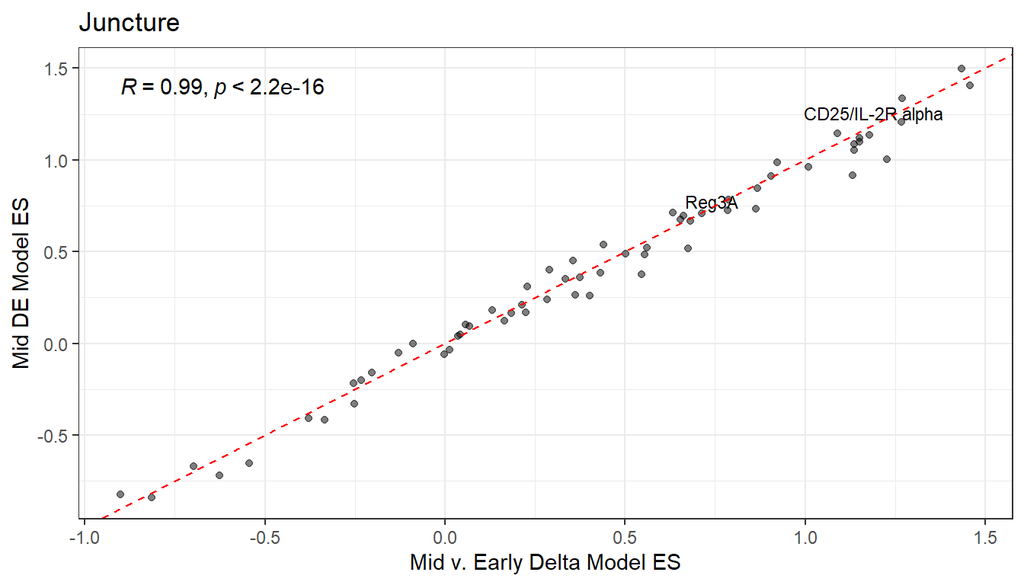

```r
ggplot(mid.did.de.df,aes(de.coef.outcomeDeceased.inferred,de.coef.outcomeDeceased,label=cytokine.label)) +
  geom_point(alpha=0.5) + ggrepel::geom_text_repel(data=subset(mid.did.de.df,cytokine.label %in% c("Reg3A","CD25/IL-2R alpha")),size=3) +
  stat_cor() + geom_abline(intercept = 0,slope = 1, color="red", linetype = "dashed") +
  theme_bw()  + labs(title="Juncture",x="Mid v. Early Delta Model ES",y="Mid DE Model ES")
```

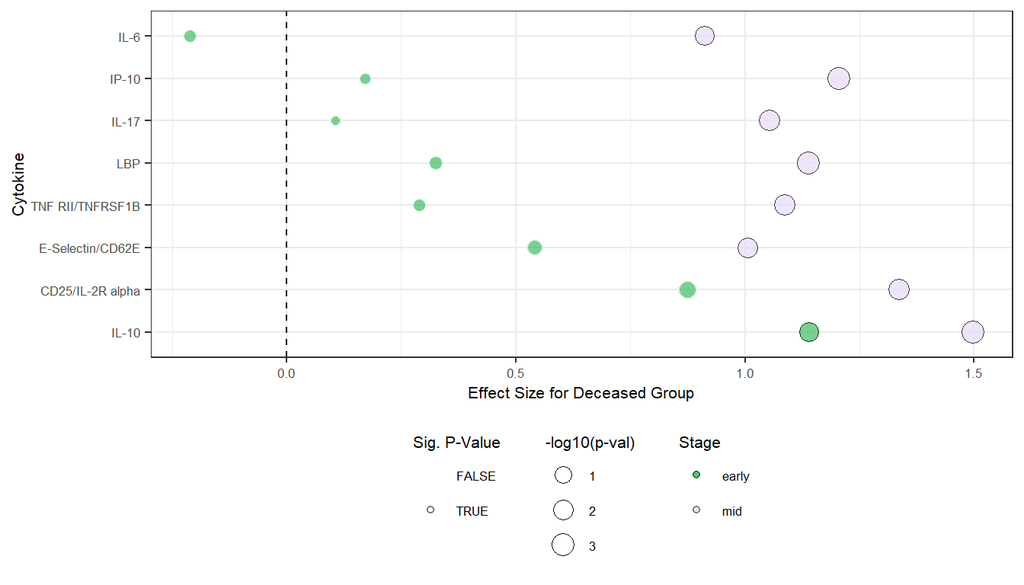

```r
sig.mid.did.de.df <- subset(mid.did.de.df,de.pval.1 <= 0.05 & did.pval.test.intervalTRUE.outcomeDeceased <= 0.05) # DE in mid & sig. delta
# order the cytokine by delta ES
sig.mid.did.de.df$cytokine.label <- factor(sig.mid.did.de.df$cytokine.label,
                                           levels=sig.mid.did.de.df$cytokine.label[order(sig.mid.did.de.df$de.coef.outcomeDeceased.diff.from.early)])
ggplot(sig.mid.did.de.df,aes(cytokine.label,de.coef.outcomeDeceased.early)) +
  geom_hline(yintercept = 0,linetype="dashed") +
  geom_point(aes(size=-log10(de.pval.1.early),color=de.pval.1.early<=0.05,fill="#4bc26c"),alpha=0.75,pch=21) +
  geom_point(aes(y=de.coef.outcomeDeceased,size=-log10(de.pval.1),color=de.pval.1<=0.05,fill="#EADCFA"),alpha=0.75,pch=21) +
  coord_flip() + ylab("Effect Size for Deceased Group") + xlab("Cytokine") +
  scale_color_manual(name="Sig. P-Value",values=c("white","black")) + scale_fill_manual(name="Stage",labels=c("early","mid"),values=c("#4bc26c","#EADCFA")) +
  scale_size(name="-log10(p-val)",range = c(2,5)) + theme_bw() + theme(text = element_text(size=8),legend.position = "bottom",legend.direction = "vertical")
```

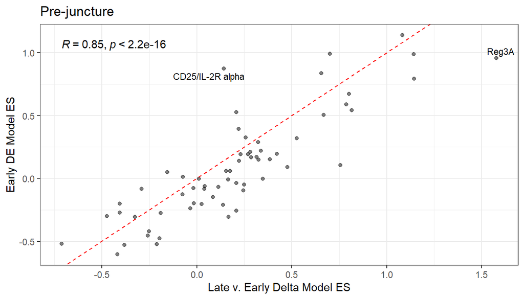

```r
# early vs. late
late.did.de.df <- subset(search.results$type1,stage == "late")
# correlation between different models
ggplot(late.did.de.df,aes(did.coef.outcomeDeceased,de.coef.outcomeDeceased.early,label=cytokine.label)) +
  geom_point(alpha=0.5) + ggrepel::geom_text_repel(data=subset(late.did.de.df,cytokine.label %in% c("Reg3A","CD25/IL-2R alpha")),size=3) +
  stat_cor() + geom_abline(intercept = 0,slope = 1, color="red", linetype = "dashed") +
  theme_bw()  + labs(title="Pre-juncture",x="Late v. Early Delta Model ES",y="Early DE Model ES")
```

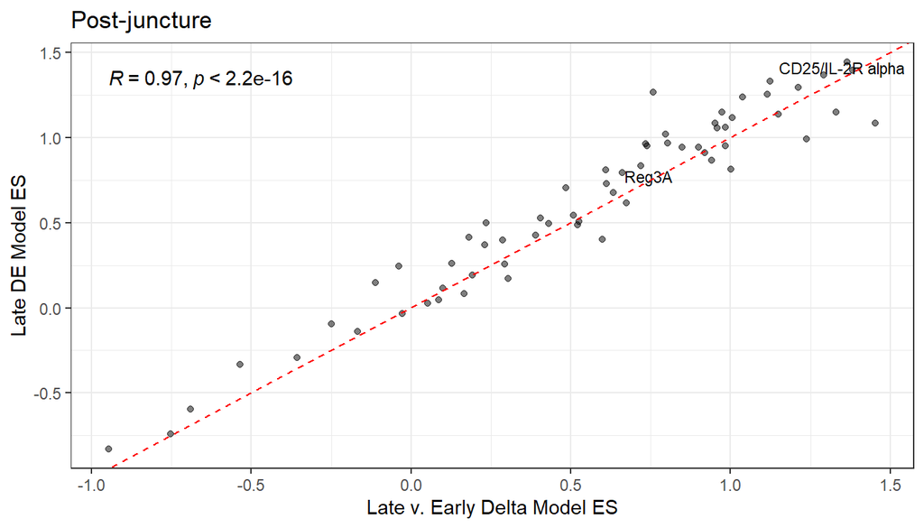

```r
ggplot(late.did.de.df,aes(de.coef.outcomeDeceased.inferred,de.coef.outcomeDeceased,label=cytokine.label)) +
  geom_point(alpha=0.5) + ggrepel::geom_text_repel(data=subset(mid.did.de.df,cytokine.label %in% c("Reg3A","CD25/IL-2R alpha")),size=3) +
  stat_cor() + geom_abline(intercept = 0,slope = 1, color="red", linetype = "dashed") +
  theme_bw()  + labs(title="Post-juncture",x="Late v. Early Delta Model ES",y="Late DE Model ES")
```

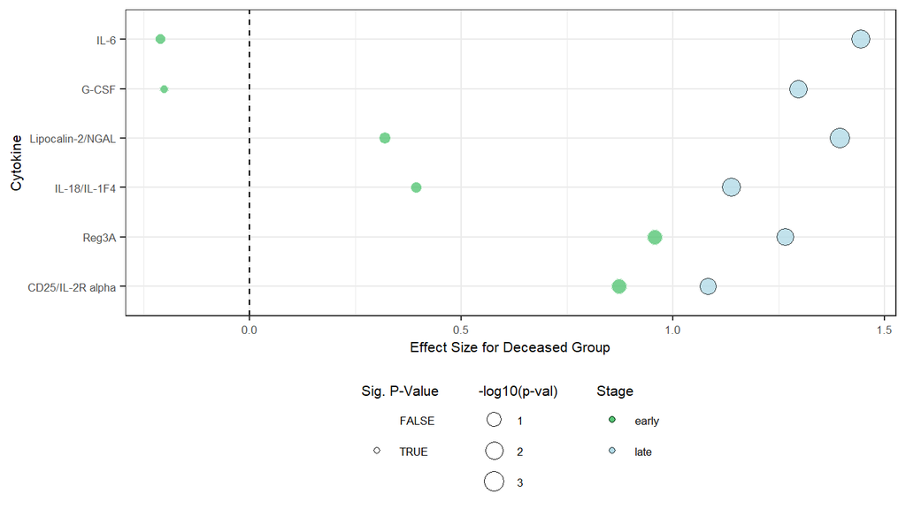

```r
sig.late.did.de.df <- subset(late.did.de.df,de.pval.1 <= 0.05 & did.pval.test.intervalTRUE.outcomeDeceased <= 0.05) # DE in mid & sig. delta
sig.late.did.de.df$cytokine.label <- factor(sig.late.did.de.df$cytokine.label,
                                        levels=sig.late.did.de.df$cytokine.label[order(sig.late.did.de.df$de.coef.outcomeDeceased.diff.from.early)])
ggplot(sig.late.did.de.df,aes(cytokine.label,de.coef.outcomeDeceased.early)) +
  geom_hline(yintercept = 0,linetype="dashed") +
  geom_point(aes(size=-log10(de.pval.1.early),color=de.pval.1.early<=0.05,fill="#4bc26c"),alpha=0.75,pch=21) +
  geom_point(aes(y=de.coef.outcomeDeceased,size=-log10(de.pval.1),color=de.pval.1<=0.05,fill="lightblue"),alpha=0.75,pch=21) +
  coord_flip() + ylab("Effect Size for Deceased Group") + xlab("Cytokine") +
  scale_color_manual(name="Sig. P-Value",values=c("white","black")) + scale_fill_manual(name="Stage",labels=c("early","late"),values=c("#4bc26c","lightblue")) +
  scale_size(name="-log10(p-val)",range = c(2,5)) + theme_bw() + theme(text = element_text(size=8),legend.position = "bottom",legend.direction = "vertical")
```

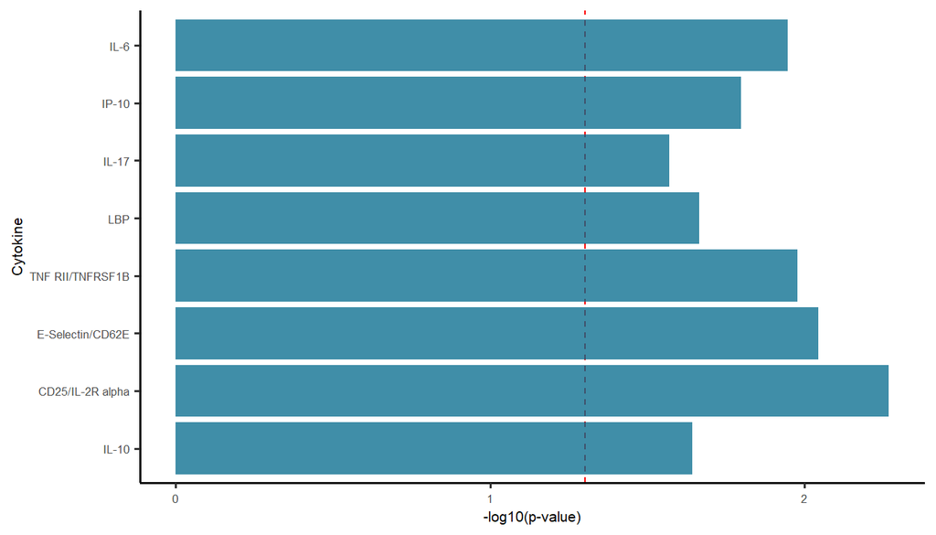

```r
#dev.off()

# delta of delta p-value plot
#pdf(file.path(output.folder,"critical.juncture","deceased.v.recovered.sig.de.and.change.cytokines.delta.pval.pdf"),width=1.75,height = 1.85)
# early vs. mid
ggplot(sig.mid.did.de.df,aes(cytokine.label,-log10(did.pval.test.intervalTRUE.outcomeDeceased))) +
  geom_hline(yintercept = -log10(0.05),linetype = "dashed",color="red") +
  geom_bar(stat="identity",fill="deepskyblue4",alpha=0.75) +
  scale_y_continuous(breaks = c(0,1,2)) +
  coord_flip() + ylab("-log10(p-value)") + xlab("Cytokine") +
  #labs(title="Deceased v. Recovered",subtitle = "At early (7-16 days) and mid (17-23 days) stages") +
  scale_color_manual(name="Sig. P-Value",values=c("white","black")) + scale_fill_manual(name="Stage",values=c("#4bc26c","#EADCFA","lightblue")) +
  scale_size(name="-log10(p-val)",range = c(2,5)) + theme_classic2() + theme(text = element_text(size=8),legend.position = "bottom",legend.direction = "vertical")
```

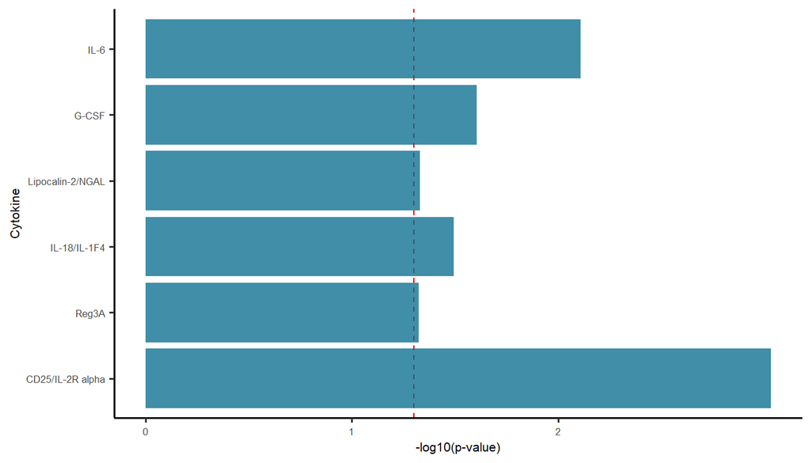

```r
ggplot(sig.late.did.de.df,aes(cytokine.label,-log10(did.pval.test.intervalTRUE.outcomeDeceased))) +
  geom_hline(yintercept = -log10(0.05),linetype = "dashed",color="red") +
  geom_bar(stat="identity",fill="deepskyblue4",alpha=0.75) +
  scale_y_continuous(breaks = c(0,1,2)) +
  coord_flip() + ylab("-log10(p-value)") + xlab("Cytokine") +
  #labs(title="Deceased v. Recovered",subtitle = "At early (7-16 days) and mid (17-23 days) stages") +
  scale_color_manual(name="Sig. P-Value",values=c("white","black")) + scale_fill_manual(name="Stage",values=c("#4bc26c","#EADCFA","lightblue")) +
  scale_size(name="-log10(p-val)",range = c(2,5)) + theme_classic2() + theme(text = element_text(size=8),legend.position = "bottom",legend.direction = "vertical")
```

```r
#dev.off()
bin1.cytokines <- list("mid"=sig.mid.did.de.df$cytokine,"late"=sig.late.did.de.df$cytokine)
```

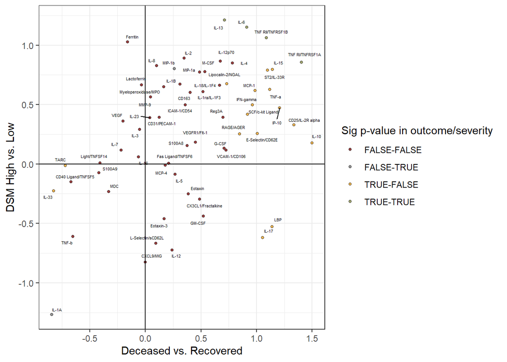

**Fig** Correlation between outcome and severity comparisons.

```r
# Correlation with DSM-high and low DE cytokines
dsm.envir <- new.env()
load(file.path(output.folder,"dsm.high.v.low.cytokine.test.results.RData"),verbose = F,envir = dsm.envir)
merged.de.df <- merge(mid.did.de.df[,c("cytokine","cytokine.label","de.coef.outcomeDeceased","de.pval.1")],
                      dsm.envir$divergence.df,by="cytokine",suffixes = c(".deceased.v.recovered","dsm.low.v.high"))
merged.de.df$combined.sig <- paste0(merged.de.df$de.pval.1 <= 0.05,"-",merged.de.df$pval.1 <= 0.05)
ggplot(merged.de.df,aes(de.coef.outcomeDeceased,-coef.dsm.groupDSM.low,label=cytokine.label.deceased.v.recovered)) +
  geom_point(alpha=0.75,pch=21,size=1,aes(fill=combined.sig)) +
  ggrepel::geom_text_repel(size=1.5,force=3) + geom_hline(yintercept = 0) + geom_vline(xintercept = 0) +
  theme_bw() + xlab("Deceased vs. Recovered") + ylab("DSM High vs. Low") + scale_fill_uchicago(name="Sig p-value in outcome/severity ")
```

```r
cat("Concordance of DE results:\n")
```

```
## Concordance of DE results:
```

```r
cont.table <- data.frame(outcome=sign(merged.de.df$de.coef.outcomeDeceased),severity=-sign(merged.de.df$coef.dsm.groupDSM.low))
table(cont.table)
```

```
##        severity
## outcome -1  1
##      -1  7  7
##      1  11 38
```

```r
fisher.test(table(cont.table))
```

```
##
##  Fisher's Exact Test for Count Data
##
## data:  table(cont.table)
## p-value = 0.08955
## alternative hypothesis: true odds ratio is not equal to 1
## 95 percent confidence interval:
##   0.8188357 14.2468645
## sample estimates:
## odds ratio
##   3.376546
```

### Time course of selected cytokines

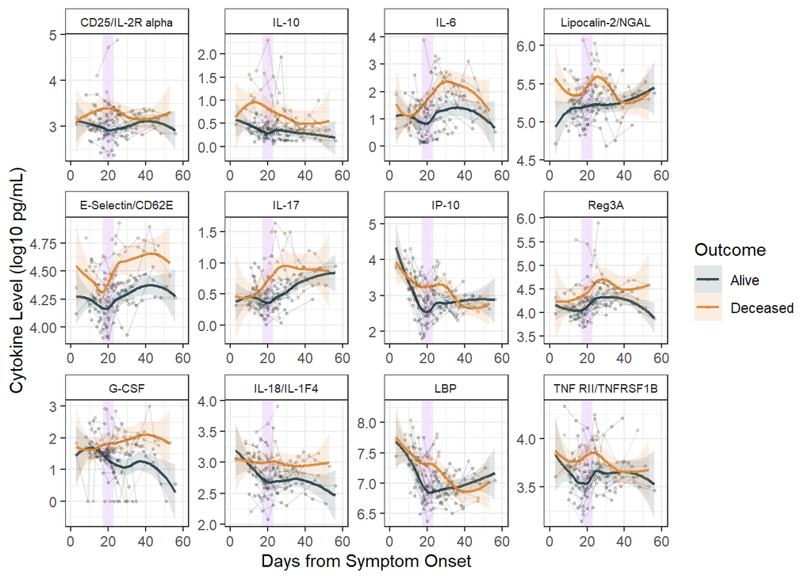

**Fig** Time course of selected circulating protein levels of critical ill patients with recovery or deceased outcomes. Longitudinal samples from the same individual are connected by gray lines. Trajectories were fitted to the two age- and gender-matched recovered versus deceased patient groups separately and are shown with the shaded areas representing standard error.

```r
display.cytokine.groups <- unique(unlist(bin1.cytokines))

display.cytokine.profiles <- subset(selected.cytokine.profiles,test_id %in% display.cytokine.groups)
#display.cytokine.profiles$test_name <- factor(display.cytokine.profiles$test_name,levels=unlist(display.cytokine.groups))

display.cytokine.profiles.avg <- aggregate(test_value ~ subject_id + days_from_symptom_onset_to_test + test_name + test_id + outcome,
                                            display.cytokine.profiles,mean)
subjects_with_early_tp <- unique(subset(display.cytokine.profiles.avg,days_from_symptom_onset_to_test <= 23)$subject_id)
ggplot(display.cytokine.profiles.avg,aes(days_from_symptom_onset_to_test,log10(test_value+1),group=outcome)) +
  #geom_vline(xintercept = 20,color="grey60",linetype="dashed") +
  geom_rect(aes(xmin=17,xmax=23,ymax=Inf,ymin=-Inf),alpha=0.05,fill = "#EADCFA") +
  geom_point(alpha=.25,pch=21,aes(fill=outcome),size=.5) +
  geom_smooth(se = T,aes(color=outcome,fill=outcome),alpha=0.15,size=.8) + #,data = subset(display.cytokine.profiles.avg,subject_id %in% subjects_with_early_tp)) +
  geom_line(aes(group=subject_id),alpha=0.1) +
  scale_color_manual(name="Outcome",values=c("#374E55FF","#DF8F44FF")) + scale_fill_manual(name="Outcome",values=c("#374E55FF","#DF8F44FF")) +
  facet_wrap(~test_name,scales = "free",ncol=5,dir = "v") + theme_bw() + xlim(0,60) +
  xlab("Days from Symptom Onset") + ylab("Cytokine Level (log10 pg/mL)") +
  theme(strip.background = element_rect(fill="white"),strip.text = element_text(size=7))
```

### Serology time course differences

SARS-Covid2 Spike and nucleocapsid antibodies

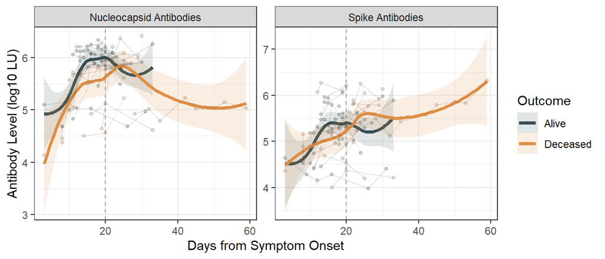

**Fig** Antibody time course for deceased and recovered patients.

```r
selected.sero.profiles <- subset(covid19.lab.results,test_type == "Serology" & subject_id %in% selected.cytokine.profiles$subject_id)
selected.sero.profiles$test_value <- log10(selected.sero.profiles$test_value+1)

ggplot(selected.sero.profiles,aes(days_from_symptom_onset_to_test,test_value)) +
  geom_vline(xintercept = 20,color="grey60",linetype="dashed") +
  geom_point(alpha=.25,pch=21,aes(fill=outcome),size=1) +
  facet_wrap(~test_name,scales = "free",ncol = 2) + theme_bw() +
  geom_smooth(se = T,aes(color=outcome,fill=outcome),alpha=0.15,size=1.25) +
  geom_line(aes(group=subject_id),alpha=0.1) +
  scale_fill_manual(name="Outcome",values=c("#374E55FF","#DF8F44FF")) +
  scale_color_manual(name="Outcome",values=c("#374E55FF","#DF8F44FF")) +
  ylab("Antibody Level (log10 LU)") + xlab("Days from Symptom Onset")
```

### CBC cell count time course

```r
selected.cbc.profiles <- subset(covid19.lab.results,test_type == "Clinical" & subject_id %in% c(recovered.patients,deceased.patients))
selected.cbc.profiles <- selected.cbc.profiles[grep("((T|C|s|\\.)_x10.[36].uL$)|[sCT]_pct$",selected.cbc.profiles$test_id),]
selected.cbc.profiles <- subset(selected.cbc.profiles,test_id %in% names(which(table(selected.cbc.profiles$test_id) > 100)))

# reference range
cell.counts.range <- unique(selected.cbc.profiles[,c("test_name","test_id","normal_range")])
cell.counts.range[,c("lower.bound","upper.bound")] <- t(sapply(cell.counts.range$normal_range,function(x){as.numeric(unlist(strsplit(x,"-")))}))
cell.counts.range <- cbind(aggregate(lower.bound ~ test_id + test_name,cell.counts.range,min),
                           upper.bound=aggregate(upper.bound ~ test_id + test_name,cell.counts.range,max)[,"upper.bound"])

# remove possible erroneous values
tolerance <- 10
to.remove.rows <- c()
for (i in unique(selected.cbc.profiles$test_id)) {
  cat(i,"\n")
  test.values <- subset(selected.cbc.profiles,test_id == i)$test_value
  median.value <- median(test.values,na.rm = T)
  range <- quantile(test.values,.75,na.rm = T) - quantile(test.values,.25,na.rm = T)
  to.remove.rows <- c(to.remove.rows,rownames(subset(selected.cbc.profiles,test_id == i &
                                                       (test_value > (median.value + tolerance*range) |
                                                       test_value < (median.value - tolerance*range)))))
}
```

```
## White.Blood.Cells.WBC_x10.3.uL
## Hematocrit.HCT_pct
## Basophils_pct
## Monocytes_x10.3.uL
## Eosinophils_x10.3.uL
## Red.Blood.Cells.RBC_x10.6.uL
## Neutrophils_pct
## Eosinophils_pct
## Monocytes_pct
## Basophils_x10.3.uL
## Lymphocytes_x10.3.uL
## Lymphocytes_pct
## Platelets.PLT_x10.3.uL
## Neutrophils_x10.3.uL
```

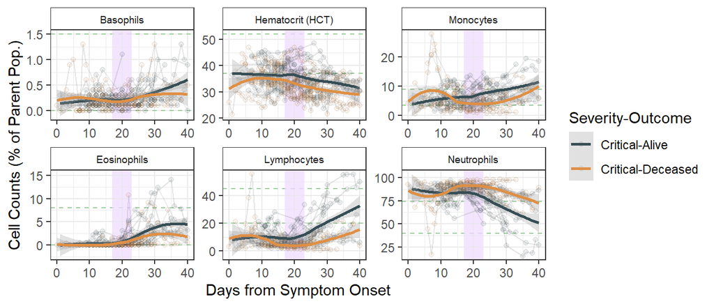

**Fig** Cell populations as % parent for deceased and recovered patients.

```r
#View(selected.cbc.profiles[to.remove.rows,])
selected.cbc.profiles <- subset(selected.cbc.profiles,!(rownames(selected.cbc.profiles) %in% to.remove.rows))

selected.cbc.profiles.avg <- aggregate(test_value ~ subject_id + days_from_symptom_onset_to_test + test_name + test_id + severity.outcome,
                                            selected.cbc.profiles,mean)
to.display <- selected.cbc.profiles.avg[grep("_pct$",selected.cbc.profiles.avg$test_id),]
ggplot(to.display) +
  geom_hline(data=subset(cell.counts.range,test_id %in% to.display$test_id),aes(yintercept=lower.bound),alpha=1,color="darkseagreen3",linetype="dashed") +
  geom_hline(data=subset(cell.counts.range,test_id %in% to.display$test_id),aes(yintercept=upper.bound),alpha=1,color="darkseagreen3",linetype="dashed") +
  geom_rect(aes(xmin=17,xmax=23,ymax=Inf,ymin=-Inf),alpha=0.05,fill = "#EADCFA") +
  #geom_vline(xintercept = 20,color="grey60",linetype="dashed") +
  geom_line(aes(x=days_from_symptom_onset_to_test,y=test_value,group=subject_id),alpha=0.1) +
  geom_point(alpha=.1,pch=21,aes(fill=severity.outcome,x=days_from_symptom_onset_to_test,y=test_value)) +
  geom_smooth(se = T,aes(x=days_from_symptom_onset_to_test,y=test_value,group=severity.outcome,color=severity.outcome),alpha=0.3) + xlim(0,40) +
  scale_color_manual(name="Severity-Outcome",values=severity.color) + scale_fill_manual(name="Severity-Outcome",values=severity.color) +
    facet_wrap(~test_name,scales = "free",ncol=5,dir = "v") + theme_bw() + ylab("Cell Counts (% of Parent Pop.)") + xlab("Days from Symptom Onset") +
    theme(strip.background = element_rect(fill="white"),strip.text = element_text(size=7))
```

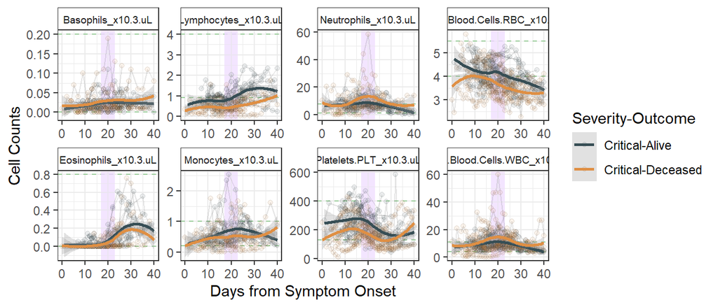

**Fig** Absolute cell counts for deceased and recovered patients.

```r
to.display <- selected.cbc.profiles.avg[grep("_pct$",selected.cbc.profiles.avg$test_id,invert = T),]
ggplot(to.display) +
 geom_hline(data=subset(cell.counts.range,test_id %in% to.display$test_id),aes(yintercept=lower.bound),alpha=1,color="darkseagreen3",linetype="dashed") +
  geom_hline(data=subset(cell.counts.range,test_id %in% to.display$test_id),aes(yintercept=upper.bound),alpha=1,color="darkseagreen3",linetype="dashed") +
  geom_rect(aes(xmin=17,xmax=23,ymax=Inf,ymin=-Inf),alpha=0.05,fill = "#EADCFA") +
  #geom_vline(xintercept = 20,color="grey60",linetype="dashed") +
  geom_line(aes(x=days_from_symptom_onset_to_test,y=test_value,group=subject_id),alpha=0.1) +
  geom_point(alpha=.1,pch=21,aes(fill=severity.outcome,x=days_from_symptom_onset_to_test,y=test_value)) +
  geom_smooth(se = T,aes(x=days_from_symptom_onset_to_test,y=test_value,group=severity.outcome,color=severity.outcome),alpha=0.3) + xlim(0,40) +
  scale_color_manual(name="Severity-Outcome",values=severity.color) + scale_fill_manual(name="Severity-Outcome",values=severity.color) +
    facet_wrap(~test_id,scales = "free",ncol=5,dir = "v") + theme_bw() + ylab("Cell Counts") + xlab("Days from Symptom Onset") +
    theme(strip.background = element_rect(fill="white"),strip.text = element_text(size=7))
```

```r
# save all results
save(merged.de.df,mid.did.de.df,late.did.de.df,file = file.path(output.folder,"deceased.v.recovered.cytokine.test.results.RData"))
```